# EDS230/ESM232 Assignment 3: Informal Sensitivity Analysis

Spring 2023

### instructions

- Develop a profit model for your almond yield (you can make this up - think about what the parameters would be)
  - you might assume a baseline profit and then adjust according to the anomaly
  - there are many ways to combine the almond yield and profit functions; you can have the profit function “call”/use the almond yield function; or create a wrapper function that calls them in sequence (first the almond yield and then the profit function)
- Do a simple informal sensitivity analysis of almond yield profit using at least 2 parameters
- Create a single graph of the results - you can decide what is the most meaningful graph

### step 1: profit model

1. Develop a profit model for your almond yield (you can make this up - think about what the parameters would be)

```r
## creating profit function here
## NPV formula - accounting for time value of money
## assuming time is by the year
## value is going to be yield
## rate is $/yield

compute_NPV = function(rate=1, value, time, discount=0.12) {
    result = rate*value / (1 + discount)**time
    return(result)
}

# load almond yield function
source("almond_model.R")

# here is what my almond yield function looks like
almond_model
```

```
## function (Tn_2, P_1, Tn_2_coeff = -0.015, Tn_2_2_coeff = -0.0046,
##     P_1_coeff = -0.07, P_1_2_coeff = 0.0043, intercept = 0.28)
## {
##     result = (Tn_2_coeff * Tn_2) + (Tn_2_2_coeff * (Tn_2)^2) +
##         (P_1_coeff * P_1) + (P_1_2_coeff * (P_1)^2) + intercept
##     return(list(yields = result, maxyield = max(result), minyield = min(result),
##         meanyield = mean(result)))
## }
```

### step 2: informal sensitivity analysis

2. Do a simple informal sensitivity analysis of total almond yield profit using at least 2 parameters

In this step, I use a wrapper function to combine the two functions for almond yield and for calculating NPV, and then take a summary statistic.

```r
climdf <- read.csv("../clim.csv", sep=" ")

# format input data
temp = climdf %>%
  group_by(month, year) %>%
  summarize_at(vars(tmin_c), list(mean)) %>%
  dplyr::filter(month==2)

pre = climdf %>% group_by(month, year) %>%
  summarize_at(vars(precip), list(sum)) %>%
  dplyr::filter(month==1)

# set up the sensitivity parameters

# r is the rate in my NPV function
r = rnorm(50, mean=2, sd=0.5)
# int is the intercept in the almond yield equation
int = rnorm(50, mean=0.28, sd=0.1)

# create data frame with both parameters, nrow = 50, so will run the model 50 times
parms = data.frame(r, int)

# here is my wrapper function: it will use each row in my 'parms' dataframe and do the following:
# 1) get almond yield, output for each year
# 2) convert yield to profit for each year
# 3) get summary statistic - in this example I am taking the total amount of profit made over the entire time period
wrapper <- function(r, int){
  yield = almond_model(Tn_2=temp$tmin_c, P_1=pre$precip, intercept = int)
  dollars = compute_NPV(value=yield$yields, rate=r, time=seq(1:length(yield$yields)))
  total_profit = sum(dollars)

  return(total_profit)
}

# this is similar to doing a for loop, except now I am going to use 'pmap' to run the wrapper
sa_parms <- pmap(parms, wrapper)

# unlist the 'pmap' results
profit_results <- data.frame(net_profit=unlist(sa_parms))

summary(profit_results)
```

```
##    net_profit
##  Min.   : 719.4
##  1st Qu.:2051.1
##  Median :2474.0
##  Mean   :2464.2
##  3rd Qu.:2869.8
##  Max.   :3553.0
```

What if we want to do the same thing but with a for loop?

```r
total_profit = vector(length=50)

for(i in 1:nrow(parms)){
  yield = almond_model(Tn_2=temp$tmin_c, P_1=pre$precip,
                       intercept = parms$int[i])
  dollars = compute_NPV(value=yield$yields, rate=parms$r[i], time=seq(1:length(yield$yields)))
  total_profit[i] = sum(dollars)
}

summary(total_profit)
```

```
##    Min. 1st Qu.  Median    Mean 3rd Qu.    Max.
##   719.4  2051.1  2474.0  2464.2  2869.8  3553.0
```

### step 3: visualize results

3. Create a single graph of the results - you can decide what is the most meaningful graph

Here you can start simple and just explore results, these are all of examples of visualizing the range of the output.

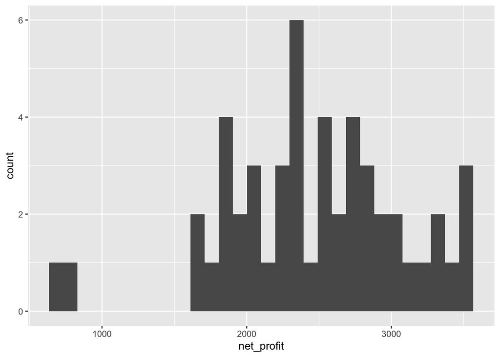

```r
ggplot(profit_results) + geom_histogram(aes(x=net_profit))
```

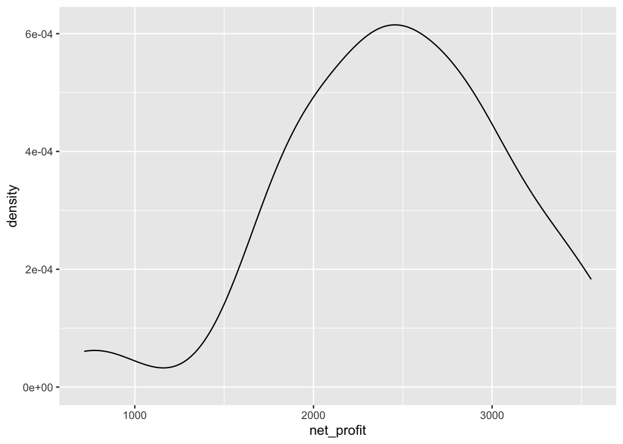

```r
ggplot(profit_results) + geom_density(aes(x=net_profit))
```

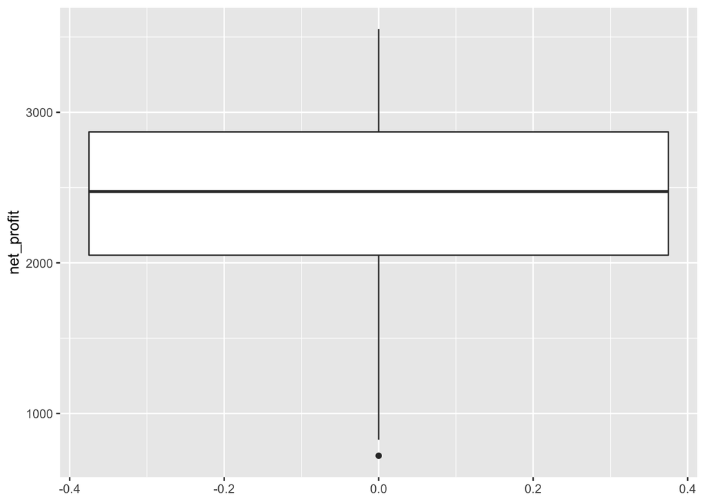

```r
ggplot(profit_results) + geom_boxplot(aes(y=net_profit))
```

We can also plot the results and how they relate to the parameters we varied

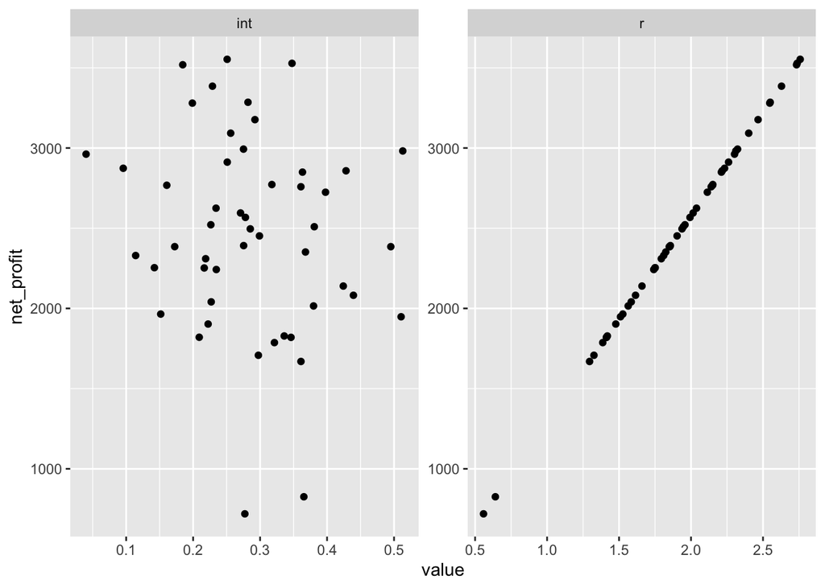

```r
# combine parms dataframe with results
# using pivot longer so that plot can use facet_grid
all_results = cbind(profit_results, parms) %>%
  pivot_longer(cols=c(r, int))

ggplot(all_results) + geom_point(aes(x=value, y=net_profit)) + facet_wrap('name', scales="free")
```